# Madrid traffic accidents app

Rafaela Becerra

March 2020

# About

The present document has all the information with respect to the app created to analize the data of traffic accidents in Madrid

The dataset use is part of the open data from Madrid and contains information about the accidents that happend in each year, updating the cases monthly

# Dataset

The dataset contains registers of people impicated in traffic accidents as the observations, the information given is:  
Number of expedient which is an id of the accident, Timing variables: Date, weather and hour of the accident Location variables: street, number and district where it happend About the accident: type of vehicle and type of accident About the victims: type of victim, age range, sex and injury level

For more information about the dataset and other datasets go to: < [Madrid Open Data](https://datos.madrid.es/)>

# Preprocess

The labels used in the dataset are records in Spanish, since they could change in time they have been trated in its original idiom.

Additionally, there are some control preprocess done in order to keep the update function of the app, like identifying from the dataset obtained from the web all the categories and variables, and create new categories for treating the data and make the calculations.

# Tabs

# Description

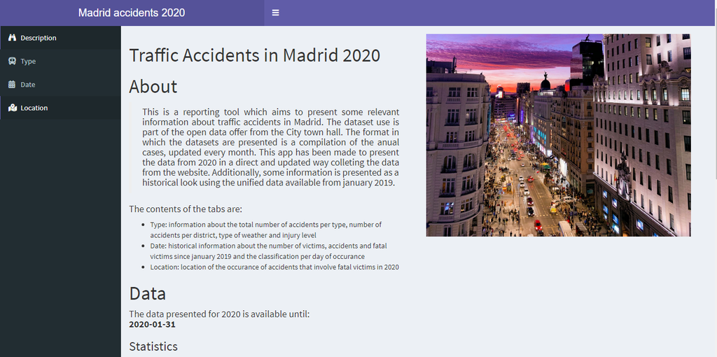

In the first tab you can find some breve description about the app, the date of the last record found on the Website and the count of accidents, victims and fatal victims until that day.

# Type

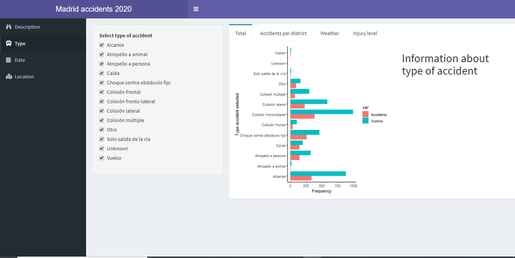

In the type tab you can select the type/types of accidents for which you want to review the information about. You will found that the information display of all the subtabs will change with your selection. The first one will present the total number of victims and accidents for each type selected and if you pass the cursor over the graph a table with the counts and type of victims will appear to the right

# Type

Additionally, you have infomation about:

- Number of accidents per district
- Number of victims classified by district
- The percentage of accidents and victims based on the weather of the day.
- The number of victims depending of their injury level, these categories have been developed in based on [this information](https://datos.madrid.es/FWProjects/egob/Catalogo/Seguridad/Ficheros/Estructura_DS_Accidentes_trafico_desde_2019.pdf)

# Date

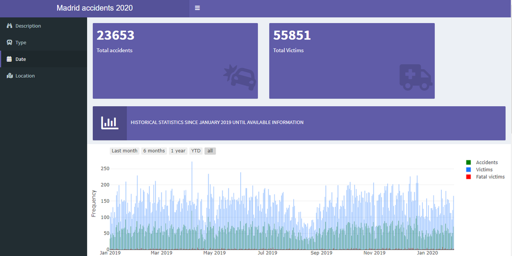

This tab contains historical infomation about registers since january 2019, the app will return automatically the hole dataset for 2019 and 2020 which is expected to be update by the website every month.

# Date

The first graph allows to see the series interactively by month, the last 6 months, 1 year from the last date, one year calendar, and all the records by selecting the buttons above it. You can also check the total number of accidents, victims and percentage of accidents based on the day on the week that they occured.

# Location

[figure not shown]

This tab displays a map that has been built by performing a geolocation function to get the location of the accidents that involved fatal victims. The points display correspond to the records of the victims that were succesfully located. You can display more information about those and the ones that could not be identified by the direcction given in the dataset.

# Packages used and references

# Packages

The packages use are the following:

- shiny
- tidyverse
- shinydashboard (instead of shinythemes for making a better looking design structure)
- magrittr (improves readability)
- lubridate (for handling dates and hours)
- plotly (interactive plots)
- tidyr (manipulation of data frames)
- shinyjs (action buttons)
- leaflet (map display)
- jsonlite (for geolocalization function)
- kableExtra (render tables to html)

# References

References checked in order to create the app:

- [Shiny HTML Tags Glossary](https://shiny.rstudio.com/articles/tag-glossary.html)
- [Shiny Tutorial](https://shiny.rstudio.com/tutorial/written-tutorial/lesson1/)
- [Shiny Articles](https://shiny.rstudio.com/articles/)
- [Plotly community](https://community.plot.ly/)
- [Shiny Dashboard](https://rstudio.github.io/shinydashboard/)
- [Shiny references](https://shiny.rstudio.com/reference/shiny/)